# Babylab data - exploration

TO DISCUSS:

- get more info on `param1`, `param2` and `corr`
- why 9 obs missing face perception task?

# 1 Intro

Here are the first descriptive stats on the babylab dataset **babylab_190502.dta**

First we present number of observations repetitions and participant characteristics.

Then we present information on the different scores provided by the experiment. In this dataset we have seven scores for two tasks: **scene perception** and **face perception and recognition**.

Vocabulary:

- fixation = definition?
- saccade = what happens between 2 fixations

# 2 Ns

- N variables in the dataset = 23
- N observations = 230
- N individuals = 177

# 3 Experiment dates

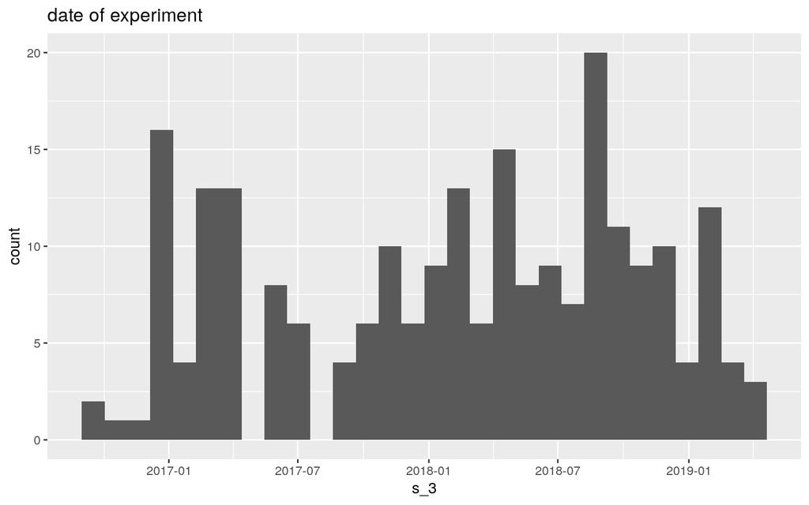

# 4 Participant sex

|  | n | % | val% |
| --- | --- | --- | --- |
| F | 75 | 42.4 | 42.4 |
| M | 102 | 57.6 | 57.6 |

# 5 Collection ages

## 5.1 Histogram

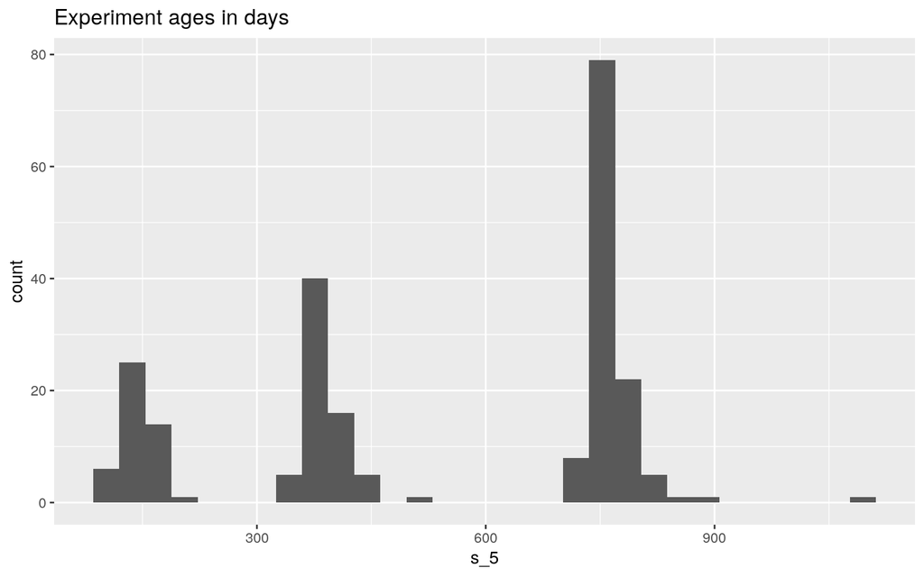

Three groups of age: 5 months, 12 months and 24 months with a majority of 24 months. Categorical age var:

|  | n | % | val% |
| --- | --- | --- | --- |
| 5 | 46 | 20.0 | 20.0 |
| 12 | 67 | 29.1 | 29.1 |
| 24 | 117 | 50.9 | 50.9 |

## 5.2 N repeated measures

Number of repeated data using the mother_token:

| n_rep | n |
| --- | --- |
| 1 | 130 |
| 2 | 41 |
| 3 | 6 |

- 130 children with 1 experiment
- 41 children with 2 experiments
- 6 children with 3 experiments

## 5.3 Repeated measure ages

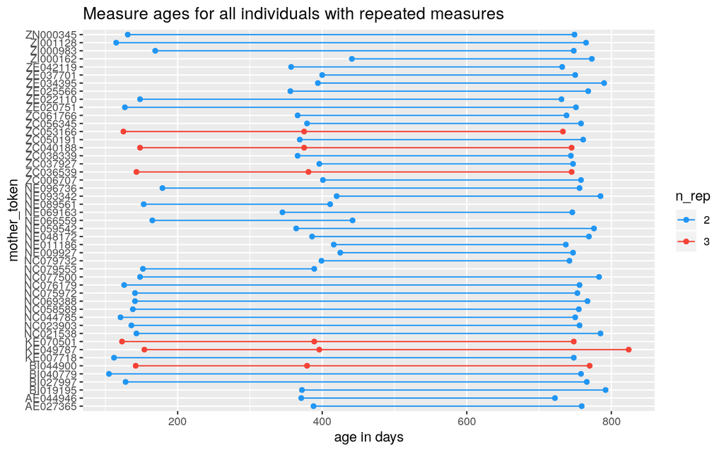

# 6 Continuous scores

First we do some univariate statistics then we look at correlations between scores.

## 6.1 Univariate

Data Frame Summary

**scores**  
**Dimensions**: 230 x 14  
**Duplicates**: 0

| **No** | **Variable** | **Label** | **Stats / Values** | **Freqs (% of Valid)** | **Graph** | **Missing** |
| --- | --- | --- | --- | --- | --- | --- |
| 1 | e1_1 [numeric] | Scene perception - SaccNum (the number of saccades) | Mean (sd) : 81.7 (16.4) min < med < max: 38 < 80.5 < 170 IQR (CV) : 18 (0.2) | 61 distinct values |  | 0 (0%) |
| 2 | e1_2 [numeric] | Scene perception - param1 (the value of a in v = b*d^a, with v = max displacem | Mean (sd) : 0.7 (0.1) min < med < max: 0.6 < 0.7 < 0.9 IQR (CV) : 0.1 (0.1) | 228 distinct values |  | 0 (0%) |
| 3 | e1_3 [numeric] | Scene perception - param2 (the value of b in v = b*d^a) | Mean (sd) : 0.7 (0.2) min < med < max: 0.2 < 0.7 < 1.4 IQR (CV) : 0.2 (0.3) | 230 distinct values |  | 0 (0%) |
| 4 | e1_4 [numeric] | Scene perception - corr (the corresponding correlation) | Mean (sd) : 1 (0) min < med < max: 0.9 < 1 < 1 IQR (CV) : 0 (0) | 223 distinct values |  | 0 (0%) |
| 5 | e1_5 [numeric] | Scene perception - MeanFixNum (the mean number of fixation over 5 seconds of pre | Mean (sd) : 7.8 (2.7) min < med < max: 0.7 < 7.8 < 13.8 IQR (CV) : 4.3 (0.3) | 64 distinct values |  | 0 (0%) |
| 6 | e1_6 [numeric] | Scene perception - MeanLT (the mean looking time over 5 seconds of presentation) | Mean (sd) : 2809.4 (850.6) min < med < max: 236.7 < 2968.7 < 4411.3 IQR (CV) : 1299.2 (0.3) | 224 distinct values |  | 0 (0%) |
| 7 | e1_7 [numeric] | Scene perception - MeanFixDur (the mean duration of one fixation) | Mean (sd) : 369.4 (63.6) min < med < max: 264 < 358.5 < 697 IQR (CV) : 79.5 (0.2) | 141 distinct values |  | 0 (0%) |
| 8 | e2_1 [numeric] | Face perception and recognition - SaccNum | Mean (sd) : 97 (16) min < med < max: 46 < 98 < 148 IQR (CV) : 21 (0.2) | 66 distinct values |  | 9 (3.91%) |
| 9 | e2_2 [numeric] | Face perception and recognition - param1 | Mean (sd) : 0.7 (0.1) min < med < max: 0.5 < 0.7 < 0.9 IQR (CV) : 0.1 (0.1) | 221 distinct values |  | 9 (3.91%) |
| 10 | e2_3 [numeric] | Face perception and recognition - param2 | Mean (sd) : 0.8 (0.2) min < med < max: 0.3 < 0.8 < 1.6 IQR (CV) : 0.3 (0.3) | 220 distinct values |  | 9 (3.91%) |
| 11 | e2_4 [numeric] | Face perception and recognition - corr | Mean (sd) : 1 (0) min < med < max: 0.9 < 1 < 1 IQR (CV) : 0 (0) | 211 distinct values |  | 9 (3.91%) |
| 12 | e2_5 [numeric] | Face perception and recognition - MeanFixNum | Mean (sd) : 12.8 (4.7) min < med < max: 1.8 < 12.9 < 24.5 IQR (CV) : 7.1 (0.4) | 110 distinct values |  | 9 (3.91%) |
| 13 | e2_6 [numeric] | Face perception and recognition - MeanLT | Mean (sd) : 5543.8 (1875.8) min < med < max: 734 < 5660 < 8986.5 IQR (CV) : 2974 (0.3) | 219 distinct values |  | 9 (3.91%) |
| 14 | e2_7 [numeric] | Face perception and recognition - MeanFixDur | Mean (sd) : 443.2 (80.3) min < med < max: 284 < 434 < 693 IQR (CV) : 105 (0.2) | 155 distinct values |  | 9 (3.91%) |

- 9 obs missing data for the face perception experiment

## 6.2 Correlations

Here we present correlations between compounds.

### 6.2.1 All scores correlations

Spearman correlations, computed on 221 complete cases.

| score | e1_1 | e1_2 | e1_3 | e1_4 | e1_5 | e1_6 | e1_7 | e2_1 | e2_2 | e2_3 | e2_4 | e2_5 | e2_6 | e2_7 |
| --- | --- | --- | --- | --- | --- | --- | --- | --- | --- | --- | --- | --- | --- | --- |
| e1_1 | 1 | 0.01 | -0.01 | 0.15 | 0.71 | 0.49 | -0.6 | 0.59 | -0.11 | 0.13 | 0.16 | 0.49 | 0.28 | -0.41 |
| e1_2 | 0.01 | 1 | -0.92 | 0.01 | -0.14 | -0.14 | 0.07 | 0.02 | 0.54 | -0.47 | 0.15 | -0.05 | -0.04 | 0.02 |
| e1_3 | -0.01 | -0.92 | 1 | -0.03 | 0.1 | 0.07 | -0.09 | -0.03 | -0.48 | 0.5 | -0.14 | 0.06 | 0.04 | -0.04 |
| e1_4 | 0.15 | 0.01 | -0.03 | 1 | 0.46 | 0.39 | -0.22 | 0 | 0 | -0.04 | 0.33 | 0.16 | 0.14 | 0 |
| e1_5 | 0.71 | -0.14 | 0.1 | 0.46 | 1 | 0.84 | -0.54 | 0.47 | -0.25 | 0.22 | 0.2 | 0.57 | 0.43 | -0.31 |
| e1_6 | 0.49 | -0.14 | 0.07 | 0.39 | 0.84 | 1 | -0.07 | 0.32 | -0.15 | 0.11 | 0.19 | 0.53 | 0.56 | -0.01 |
| e1_7 | -0.6 | 0.07 | -0.09 | -0.22 | -0.54 | -0.07 | 1 | -0.41 | 0.23 | -0.24 | -0.03 | -0.29 | 0.01 | 0.6 |
| e2_1 | 0.59 | 0.02 | -0.03 | 0 | 0.47 | 0.32 | -0.41 | 1 | -0.14 | 0.16 | 0.06 | 0.7 | 0.41 | -0.61 |
| e2_2 | -0.11 | 0.54 | -0.48 | 0 | -0.25 | -0.15 | 0.23 | -0.14 | 1 | -0.95 | 0.08 | -0.31 | -0.24 | 0.15 |
| e2_3 | 0.13 | -0.47 | 0.5 | -0.04 | 0.22 | 0.11 | -0.24 | 0.16 | -0.95 | 1 | -0.06 | 0.31 | 0.23 | -0.17 |
| e2_4 | 0.16 | 0.15 | -0.14 | 0.33 | 0.2 | 0.19 | -0.03 | 0.06 | 0.08 | -0.06 | 1 | 0.27 | 0.32 | 0.1 |
| e2_5 | 0.49 | -0.05 | 0.06 | 0.16 | 0.57 | 0.53 | -0.29 | 0.7 | -0.31 | 0.31 | 0.27 | 1 | 0.87 | -0.35 |
| e2_6 | 0.28 | -0.04 | 0.04 | 0.14 | 0.43 | 0.56 | 0.01 | 0.41 | -0.24 | 0.23 | 0.32 | 0.87 | 1 | 0.1 |
| e2_7 | -0.41 | 0.02 | -0.04 | 0 | -0.31 | -0.01 | 0.6 | -0.61 | 0.15 | -0.17 | 0.1 | -0.35 | 0.1 | 1 |

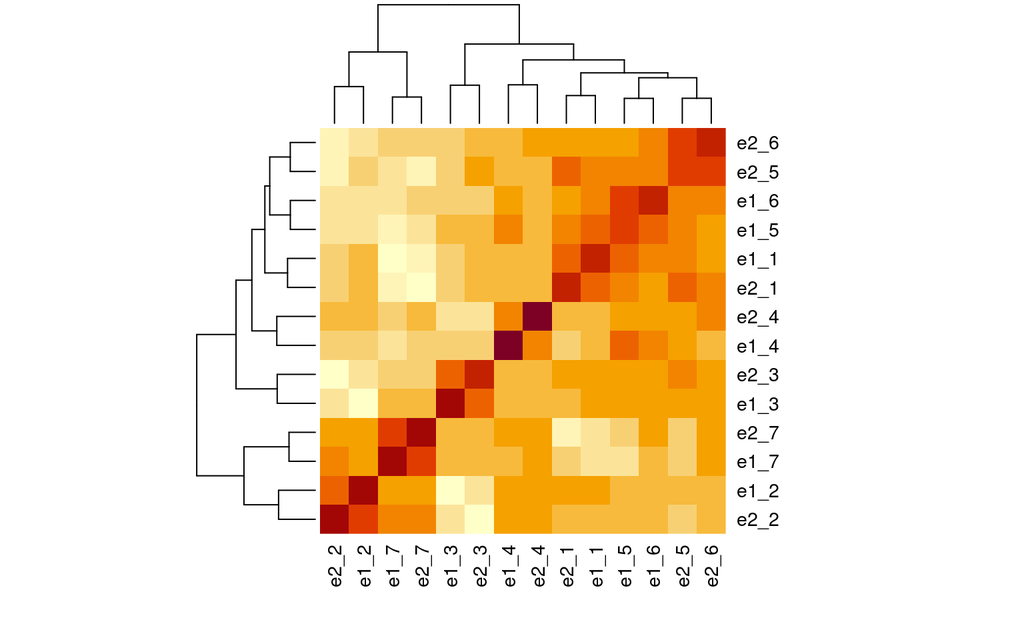

### 6.2.2 Scene perception

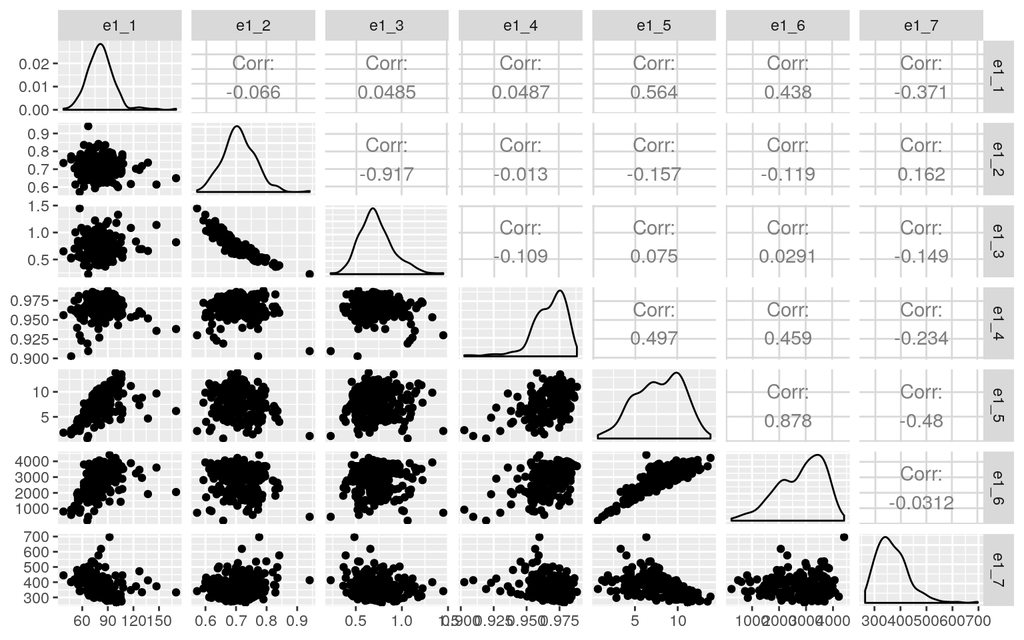

### 6.2.3 Face perception and recognition

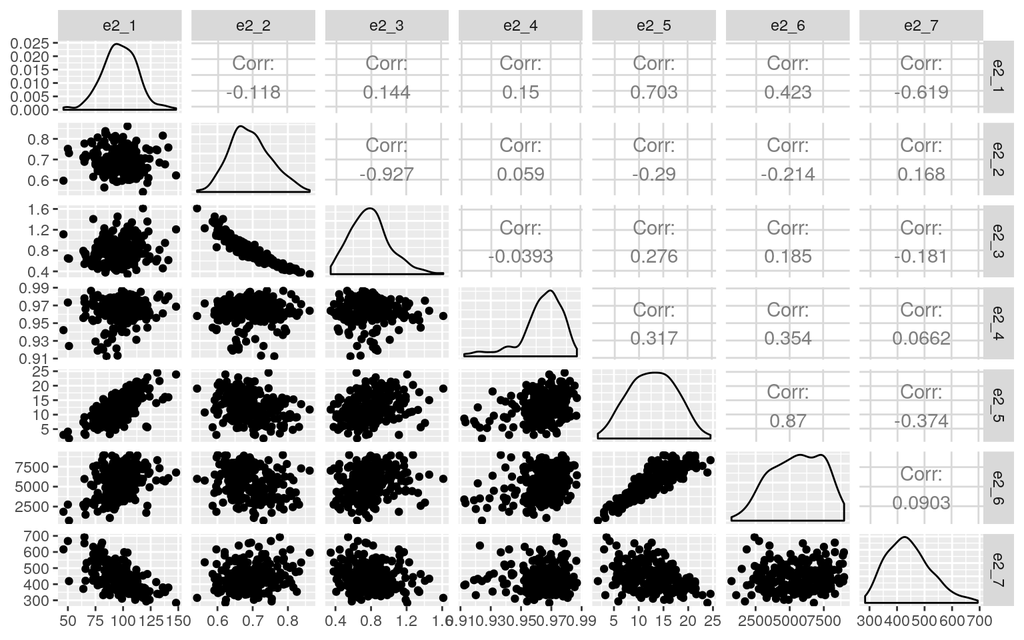

### 6.2.4 Repeated measures

Correlation for each score between each period (5 months, 12 months and 24 months):

| task | cor_5_12 | n_1 | cor_12_24 | n_2 | cor_5_24 | n_3 |
| --- | --- | --- | --- | --- | --- | --- |
| e1_1 | 0.67 | 9 | 0.65 | 27 | 0.27 | 23 |
| e1_2 | 0.13 | 9 | 0.29 | 27 | 0.15 | 23 |
| e1_3 | 0.25 | 9 | 0.28 | 27 | 0.09 | 23 |
| e1_4 | -0.02 | 9 | -0.01 | 27 | 0.13 | 23 |
| e1_5 | 0.20 | 9 | 0.62 | 27 | 0.33 | 23 |
| e1_6 | -0.05 | 9 | 0.42 | 27 | 0.21 | 23 |
| e1_7 | 0.98 | 9 | 0.74 | 27 | 0.27 | 23 |
| e2_1 | 0.31 | 6 | 0.48 | 25 | 0.25 | 20 |
| e2_2 | -0.14 | 6 | 0.46 | 25 | 0.16 | 20 |
| e2_3 | 0.09 | 6 | 0.43 | 25 | 0.20 | 20 |
| e2_4 | -0.26 | 6 | 0.44 | 25 | -0.04 | 20 |
| e2_5 | 0.46 | 6 | 0.51 | 25 | 0.37 | 20 |
| e2_6 | 0.31 | 6 | 0.37 | 25 | 0.43 | 20 |
| e2_7 | 0.26 | 6 | 0.54 | 25 | 0.60 | 20 |

### 6.2.5 Conclusions

Scores that seem to be positively correlated:

- Mean looking time and mean number of fixations within each tasks
- All other scores between tasks (eg mean fixation duration for task 1 and for task 2)

Scores that seem to be negatively correlated:

- param1 and param2 within each task

Matthieu Rolland

2019-11-29